# MH3511 Lab 9 Notes

Caleb Tay (caleb.tay@ntu.edu.sg)

30 Mar 2026

# Exercise 9.1

This tutorial deals with nonparametric data, i.e. we do not assume a distribution on our data. We do still need a distribution for our test statistic, though.

We have null hypothesis $H_0:$ the median exam score of the high school graduates is 180 (or less), and alternative hypothesis $H_1:$ the median exam score is more than 180. Symbolically, $H_0: \textrm{median} \leq 180$, $H_1: \textrm{median} > 180$.

Under the null hypothesis, if the median is indeed 180, then 50% of the data should be above 180, and 50% of the data should be below 180. A binomial distribution is useful for this model, since either an exam score is above 180 or below 180.

Here, we have 15 observations, so we should expect 7.5 to be below 180. If the median was **higher** than 180 (if the alternative hypothesis is true), then we should expect less than 7.5 to be below 180. Symbolically, writing $T$ to be the number of observations below the median, under the null hypothesis we have $T \sim \textrm{Binomial}(15, 0.5)$.

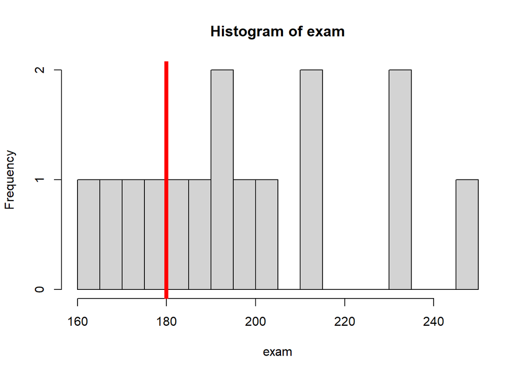

```r
exam <- c(189, 233, 195, 160, 212, 176, 231, 185,
          199, 213, 202, 193, 174, 166, 248)

hist(exam, breaks=15)
abline(v=180, col="red", lwd=5)
```

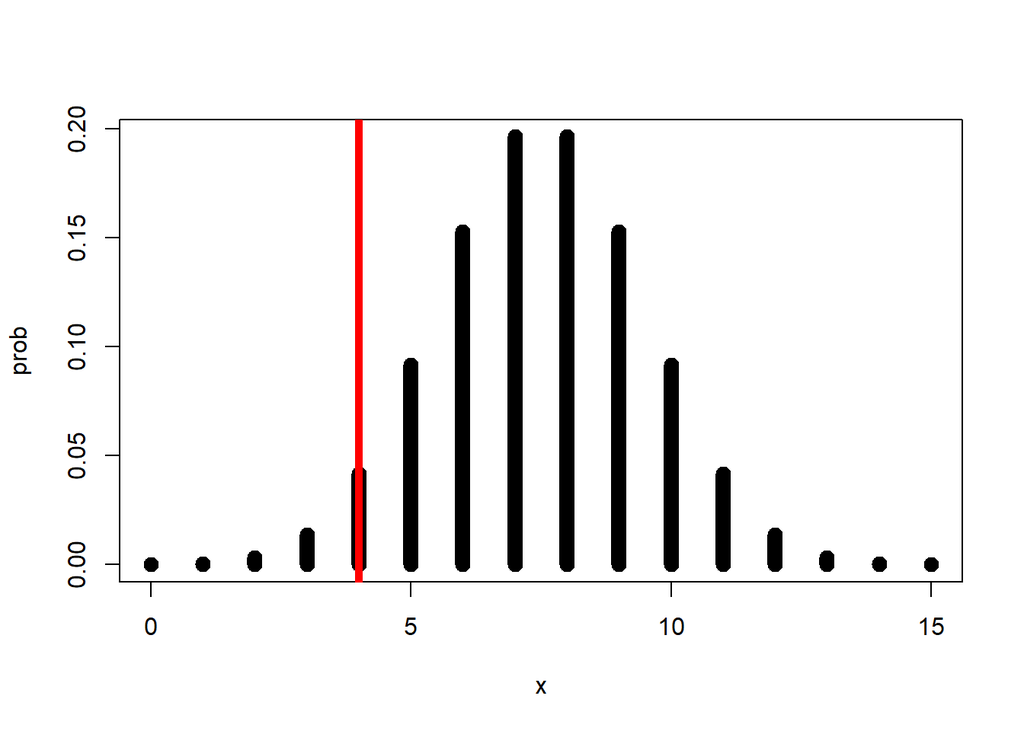

```r
t <- sum(exam <= 180)

x <- 0:15
prob <- dbinom(x, 15, 0.5)
plot(x, prob, type='h', lwd = 10)
abline(v=t, col="red", lwd = 5)
```

```r
pbinom(t, 15, 0.5)
```

```
## [1] 0.05923462
```

```r
quantile.test <- function(x, xp=0, quantile=0.5, alternative="two.sided") {
  n <- length(x)
  p <- quantile
  t1 <- sum(x <= xp)
  t2 <- sum(x < xp)

  if (alternative == "quantile.less") {
    p.value <- 1 - pbinom(t2 - 1, n, p)
  } else if (alternative == "quantile.greater") {
    p.value <- pbinom(t1, n, p)
  } else if (alternative == "two.sided") {
    p.value <- 2 * min(1 - pbinom(t2-1, n, p), pbinom(t1, n, p))
  }
  cat(paste("null =", quantile, "quantile is", xp, ";  alternative =", alternative, "\n"))
  cat(paste("observed median =", quantile(x, 0.5), ";  t1 =", t1, ";  t2 =", t2, ";  p.value =", p.value, "\n"))
}

quantile.test(exam, 180, 0.5, alternative="quantile.greater")
```

```
## null = 0.5 quantile is 180 ;  alternative = quantile.greater
## observed median = 195 ;  t1 = 4 ;  t2 = 4 ;  p.value = 0.059234619140625
```

```r
quantile.test(exam, 180, 0.5, alternative="quantile.less")
```

```
## null = 0.5 quantile is 180 ;  alternative = quantile.less
## observed median = 195 ;  t1 = 4 ;  t2 = 4 ;  p.value = 0.982421875
```

The definition of `t2` as `sum(x < xp)` is to get the symmetric right-sided value, since the binomial distribution is symmetric.

$$P(T \geq x_p) = 1 - P(T < x_p) = 1 - P(T \leq x_p - 1)$$

# Exercise 9.2

The Wilcoxon rank-sum test is used for comparing two samples. Order the data with the groups and consider their ranking. If we have $n$ observations ranked, the ranks go from $1$ to $n$, with a rank-sum of $\frac{n(n+1)}{2}$. Under the null hypothesis, if the two groups have the same distribution, then their rank-sum should be near the rank-sum weighted by the number of observations in each group.

```r
area <- c(rep("A", 3), "B", "A", rep("B", 4))
rank <- 1:9

rank.sum.A <- sum(rank[area=="A"])
rank.sum.B <- sum(rank[area=="B"])
n.A <- sum(area == "A")
n.B <- sum(area == "B")
rank.sum.A.expected <- n.A / length(area) * sum(rank)
rank.sum.B.expected <- n.B / length(area) * sum(rank)
rank.sum.A; rank.sum.A.expected
```

```
## [1] 11
```

```
## [1] 20
```

The test statistic in R is computed slightly differently, subtracting the minimum rank-sum the group could take (i.e. if 4 observations, ranks 1 to 4).

```r
rank.sum.A - n.A*(n.A+1)/2
```

```
## [1] 1
```

```r
wilcox.test(rank ~ area)
```

```
##
##  Wilcoxon rank sum exact test
##
## data:  rank by area
## W = 1, p-value = 0.03175
## alternative hypothesis: true location shift is not equal to 0
```

The distribution of the test statistic $W$ here is kind of binomial, but is [not trivially easy to compute](https://github.com/scipy/scipy/pull/4933#issuecomment-1898082691). Essentially it is counting the number of ways to get that rank-sum. The minimum possible is occupying all of the first $n$ ranks, and the maximum value all of the last $n$ ranks.

For bigger sample sizes, the test statistic is approximately normal, but the variance is a bit of a mess to compute.

# Exercise 9.3

The Kruskal-Wallis rank-sum test extends the Wilcoxon rank-sum test to more than 2 groups. It is similar to the ANOVA test in that we are testing for **any** difference among the groups.

```r
program <- rep(c("A", "B", "C", "D"), rep(5, 4))
ranks <- c(4, 6, 7, 2, 10,
           1, 8, 12, 3, 11,
           20, 19, 16, 14, 5,
           18, 15, 17, 13, 9)

rank.sums <- aggregate(ranks ~ program, FUN=sum)$ranks
rank.sums.expected <- sum(ranks) / 4
```

```r
kruskal.test(ranks, program)
```

```
##
##  Kruskal-Wallis rank sum test
##
## data:  ranks and program
## Kruskal-Wallis chi-squared = 9.72, df = 3, p-value = 0.0211
```

Once we have confirmed there is a difference within the groups, we can do a pairwise Wilcoxon rank-sum test, similar to ANOVA then pairwise t-tests.

Similar to the ANOVA test, the aim of the Kruskal-Wallis test is to identify if there is any difference among the groups while **keeping the type-I error rate constant**. Here, with 4 groups, there would be 6 pairwise tests to conduct, which with a type-I error rate (significance level) of 5%, leads to at least one type-I error among the 6 pairwise tests occurring 26.5% of the time.

```r
pairwise.wilcox.test(ranks, program, p.adjust.method = "none")
```

```
##
##  Pairwise comparisons using Wilcoxon rank sum exact test
##
## data:  ranks and program
##
##   A     B     C
## B 0.690 -     -
## C 0.056 0.056 -
## D 0.016 0.032 0.690
##
## P value adjustment method: none
```